# a3_task3_nikole_vannest

Nikole Vannest

11/1/2020

```r
knitr::opts_chunk$set(echo = TRUE)
library(tidyverse)
library(here)
library(janitor)
library(kableExtra)
library(lubridate)
```

## Section 1: Size comparisons

In the following code chunks I will create a exploratory data visuals comparing sizes of purple and red sea urchins.

Data source: Reed, D. 2020. SBC LTER: Reef: Long-term experiment: Kelp removal: Urchin size frequency distribution ver 20. Environmental Data Initiative. Click [here](https://doi.org/10.6073/pasta/5a1e9ef03aa47bd2225c0bb98a02a63b) for more info.

```r
sea_urchins <- read.csv(here("data", "urchins.csv")) #Read in csv file

urchins <- sea_urchins %>%
  clean_names() #clean up the column names
```

#### Exploratory histogram

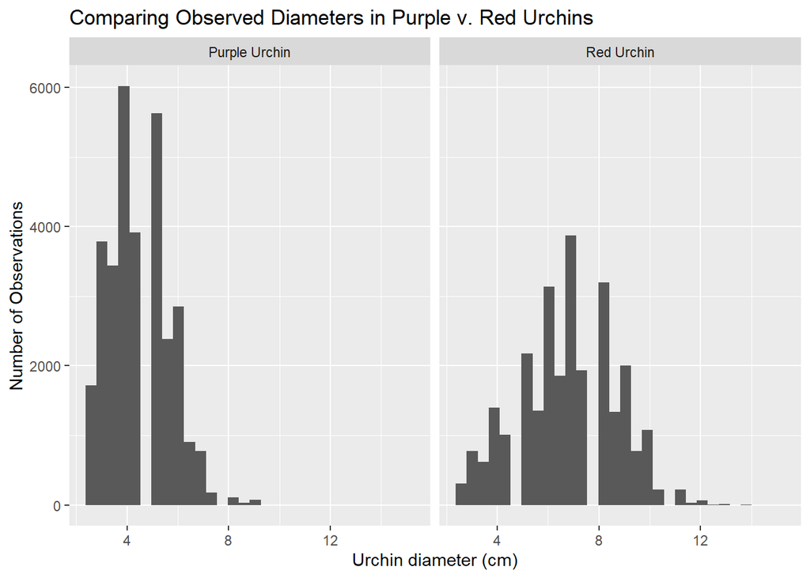

```r
ggplot(data = urchins, aes(x = size)) +
  geom_histogram() +
  facet_wrap(~common_name) + #split up graph by common name
  labs(x ="Urchin diameter (cm)", #Update axis labels and title
       y = "Number of Observations",
       title = "Comparing Observed Diameters in Purple v. Red Urchins")
```

#### Exploratory boxplot

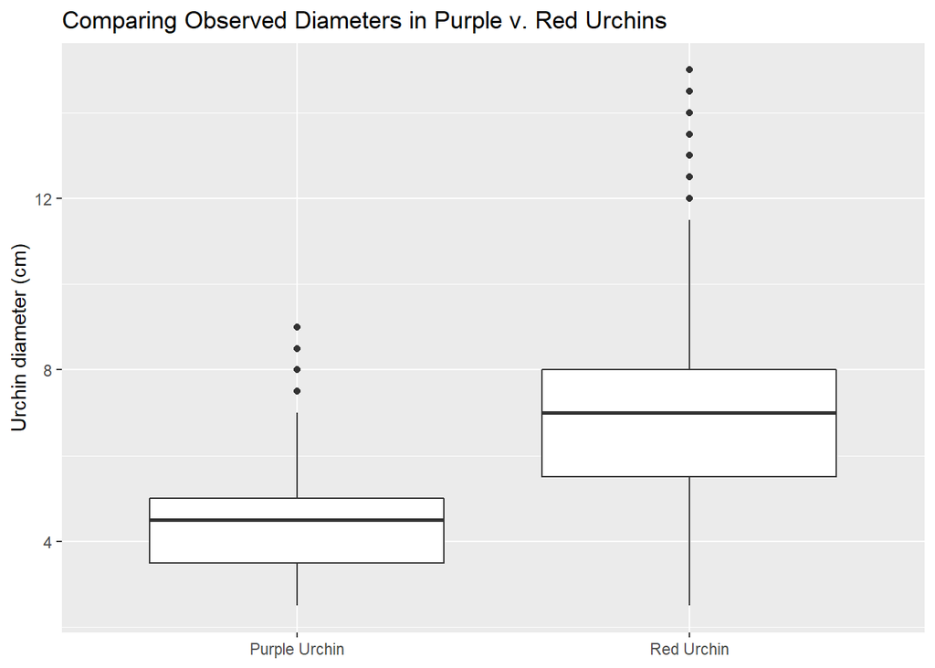

```r
ggplot(data = urchins, aes(x = common_name, y = size)) +
  geom_boxplot() +
  labs(x = c(), #Leave empty, label already defined.
       y = "Urchin diameter (cm)", #Update axis labels and title
       title = "Comparing Observed Diameters in Purple v. Red Urchins")
```

#### Summary statistics table including mean, median, standard deviation and number of observations

```r
urchin_table <- urchins %>%
  group_by(common_name) %>%
  summarize(mean_size = mean(size),
            median_size = median(size),
            sd_size = sd(size),
            n = n())

kable(urchin_table) %>% #using kable function for table, neat!
  kable_styling(latex_options = "scale_down") #Spread out col names so is readable
```

| common_name | mean_size | median_size | sd_size | n |
| --- | --- | --- | --- | --- |
| Purple Urchin | 4.469797 | 4.5 | 1.175264 | 31805 |
| Red Urchin | 6.776489 | 7.0 | 1.891343 | 27408 |

```r
purple <- urchin_table %>%
  filter(common_name == "Purple Urchin") #separate table into individual urchin types
red <-  urchin_table %>%
  filter(common_name == "Red Urchin")

percent_diff <- abs((purple$mean_size - red$mean_size)/((purple$mean_size + red$mean_size)/2))*100 #find percent difference between means
abs(purple$mean_size - red$mean_size) #actual difference in means
```

```
## [1] 2.306691
```

```r
percent_diff
```

```
## [1] 41.02139
```

**In context:** In the figures and table above, data is compared between two species of sea urchin, red and purple. The actual difference of the mean diameter is 2.31 cm, and the percent difference is 41%. This is consistent with the information we are getting from the boxplot above, showing a fairly clear difference in means that would imply these are two distinctly separate groups based on their diameter alone.

## Section 2: Exploring purple urchin counts by year and site

Below the data is cleaned up for the data subset ‘Purple Urchins’ and information regarding the site column has been updated to site_full to include the full name of the site.

```r
purple_urchins <- urchins %>%
  filter(common_name == "Purple Urchin") %>%
  mutate(date = mdy(date)) %>%
  mutate(year = year(date)) %>%
  mutate(site_full = case_when(
    site %in% "NAPL" ~ "Naples Reef",
    site %in% "AQUE" ~ "Arroyo Quemando Reef",
    site %in% "CARP" ~ "Carpinteria Reef",
    site %in% "MOHK" ~ "Mohawk Reef",
    site %in% "IVEE" ~ "Isla Vista Reef"
  ))
```

### Summary Table

```r
purple_summary <- purple_urchins %>%
  group_by(site, year) %>%
  summarize(n = n())
```

### Exploratory Graph

Displays number of urchins at each site for years recorded

[figure not shown]

```r
ggplot(purple_urchins, aes(x = year)) +
  geom_histogram() +
  facet_wrap(~site_full) +
  labs(x = "Year",
       y = "Number of Observations",
       title = "Number of Purple Urchins Observed Between 2008-2019")
```